# Analyzing effect of simulation length

František Kalvas

Department of Sociology, University of West Bohemia in Pilsen

2022-03-24

## Introduction

Main focus of this side project is to find phase-transition which happen when we are changing boundary/`acceptability of different opinion`. Result should be a simple graph showing how ESBG polarization changes with change of `acceptability of different opinion`.

## Loading data

Data are at http://github.com/frantisek901/Spirals/Experiment. Experiment is done, I actualized the `*.csv` files at GitHub, then I ran script `experiment.R` which loads the data. Now, 2022-03-23, we are completely done. Who is not interested in working with megabytes of `*.csv files`, might use compiled `phase.RData`.

Now we load, join and aggregate these data and factorize and rename selected variables:

```r
## Loading stored data
load("shortData1D.RData")
load("longData1D.RData")
load("shortData.RData")
load("longData.RData")


## Joining data
df = inner_join(
  long1D %>% select(RS:`[step]`, ESBG_ls = ESBSG_polarization_start, ESBG_lf = ESBG_3650, -`max-ticks`) %>%
    prejmenuj(c(3, 5:7, 10:12), c("identity", "conformity", "neis", "random", "tolerance", "speaking", "step_lf")),
  res1D %>% select(RS:`[step]`, ESBG_ss = ESBSG_polarization_start, ESBG_sf = ESBG_365, -`max-ticks`) %>%
    prejmenuj(c(3, 5:7, 10:12), c("identity", "conformity", "neis", "random", "tolerance", "speaking", "step_sf"))
  ) %>%
  add_row(
    inner_join(
      long %>% select(c(2, 3, 13, 5, 17, 8, 7, 9:12, 18),
                      ESBG_ls = ESBSG_polarization_start, ESBG_lf = ESBG_3650, -`max-ticks`) %>%
        prejmenuj(c(3, 5:7, 10:12), c("identity", "conformity", "neis", "random", "tolerance", "speaking", "step_lf")),
      res %>% select(c(2, 3, 12, 4, 13, 7, 6, 8:11, 14),
                     ESBG_ss = ESBSG_polarization_start, ESBG_sf = ESBG_365, -`max-ticks`) %>%
        prejmenuj(c(3, 5:7, 10:12), c("identity", "conformity", "neis", "random", "tolerance", "speaking", "step_sf"))
      )
    ) %>%

  ## Balancing files to get them proportionally same:
  distinct() %>%  # here we leave out duplicate observations -- I checked that these dulicities have same results
  filter((opinions == 1 & RS <= 10) | (opinions == 2 & RS > 10 & RS <= 20), neis > 13, mode == "openly-listen") %>%

  ## Creating needed variables:
  mutate(
    id_threshold = if_else(identity, id_threshold, NA_real_) %>% factor(exclude = ""),
    ESBG_diff = ESBG_lf - ESBG_sf,
    ESBG_dcat = case_when(
      ESBG_diff <= -0.1                     ~ "Decrease",
      ESBG_diff <= -0.01 & ESBG_diff > -0.1 ~ "Slight decrease",
      ESBG_diff >= 0.01 & ESBG_diff < 0.1   ~ "Slight increase",
      ESBG_diff >= 0.1                      ~ "Increase",
      TRUE                                  ~ "Roughly equal"
    ) %>% factor(levels = c("Decrease", "Slight decrease", "Roughly equal", "Slight increase", "Increase")),
    across(.cols = c(opinions:mode, tolerance, speaking), ~factor(.x))
  )

## Removing not needed objects:
rm(long, long1D, res, res1D)
```

## Graphs: Description

Now, let’s show our results graphically!

### Change of polarization

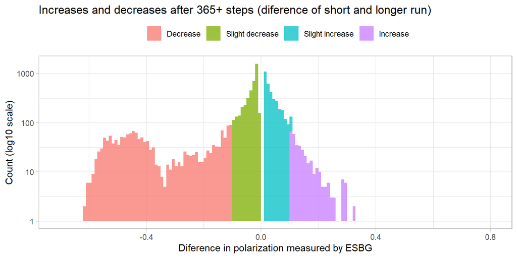

```r
df %>% filter(ESBG_dcat != "Roughly equal") %>%
  ggplot() +
  aes(x = ESBG_diff, fill = ESBG_dcat) +
  geom_histogram(alpha = 0.75,
                 breaks = seq(-0.7004, 0.8004, 0.01)) +
  scale_y_log10() +
  labs(title = "Increases and decreases after 365+ steps (diference of short and longer run)",
       x = "Diference in polarization measured by ESBG", y = "Count (log10 scale)", fill = "") +
  theme_light() +
  theme(legend.position = "top")
```

```r
df %>% frq(ESBG_dcat, show.na = F) %>% kable()
```

| val | label | frq | raw.prc | valid.prc | cum.prc |
| --- | --- | --- | --- | --- | --- |
| Decrease |  | 1685 | 9.75 | 9.75 | 9.75 |
| Slight decrease |  | 4016 | 23.24 | 23.24 | 32.99 |
| Roughly equal |  | 7948 | 46.00 | 46.00 | 78.99 |
| Slight increase |  | 3283 | 19.00 | 19.00 | 97.99 |
| Increase |  | 348 | 2.01 | 2.01 | 100.00 |

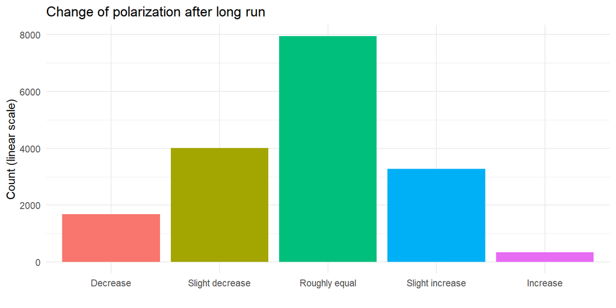

```r
df %>%
  ggplot() +
  aes(x = ESBG_dcat, fill = ESBG_dcat) +
  geom_bar() +
  labs(title = "Change of polarization after long run",
       x = "", y = "Count (linear scale)") +
  guides(fill = "none") +
  theme_minimal() +
  theme(legend.position = "top")
```

This is less evident but still evident that there is more decrease than increase. Previous graph wass better.

### Natural end of simulations

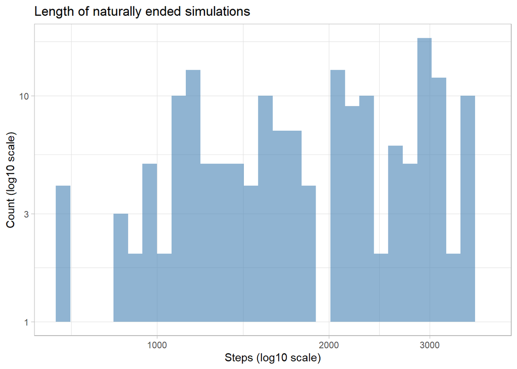

```r
df %>% filter(step_lf < 3649) %>%
  ggplot() +
  aes(x = step_lf) +
  geom_histogram(fill = "steelblue", alpha = 0.6) +
  scale_y_log10() +
  scale_x_log10() +
  labs(title = "Length of naturally ended simulations",
       x = "Steps (log10 scale)", y = "Count (log10 scale)") +
  theme_light()
```

## Inspection of `df`

Let’s check whether the reduced file is balanced:

```r
df %>% group_by(opinions, identity) %>% frq(RS, show.na = F)
```

```
## RS <numeric>
## # grouped by: 1, FALSE
## # total N=2160 valid N=1944 mean=5.50 sd=2.87
##
## Value |   N | Raw % | Valid % | Cum. %
## --------------------------------------
##     1 | 216 |    10 |      10 |     10
##     2 | 216 |    10 |      10 |     20
##     3 | 216 |    10 |      10 |     30
##     4 | 216 |    10 |      10 |     40
##     5 | 216 |    10 |      10 |     50
##     6 | 216 |    10 |      10 |     60
##     7 | 216 |    10 |      10 |     70
##     8 | 216 |    10 |      10 |     80
##     9 | 216 |    10 |      10 |     90
##    10 | 216 |    10 |      10 |    100
##
## RS <numeric>
## # grouped by: 1, TRUE
## # total N=6480 valid N=5832 mean=5.50 sd=2.87
##
## Value |   N | Raw % | Valid % | Cum. %
## --------------------------------------
##     1 | 648 |    10 |      10 |     10
##     2 | 648 |    10 |      10 |     20
##     3 | 648 |    10 |      10 |     30
##     4 | 648 |    10 |      10 |     40
##     5 | 648 |    10 |      10 |     50
##     6 | 648 |    10 |      10 |     60
##     7 | 648 |    10 |      10 |     70
##     8 | 648 |    10 |      10 |     80
##     9 | 648 |    10 |      10 |     90
##    10 | 648 |    10 |      10 |    100
##
## RS <numeric>
## # grouped by: 2, FALSE
## # total N=2160 valid N=1944 mean=15.50 sd=2.87
##
## Value |   N | Raw % | Valid % | Cum. %
## --------------------------------------
```

[output cut: 12 more lines]

```
## # grouped by: 2, TRUE
## # total N=6480 valid N=5832 mean=15.50 sd=2.87
##
## Value |   N | Raw % | Valid % | Cum. %
## --------------------------------------
##    11 | 648 |    10 |      10 |     10
##    12 | 648 |    10 |      10 |     20
##    13 | 648 |    10 |      10 |     30
##    14 | 648 |    10 |      10 |     40
##    15 | 648 |    10 |      10 |     50
##    16 | 648 |    10 |      10 |     60
##    17 | 648 |    10 |      10 |     70
##    18 | 648 |    10 |      10 |     80
##    19 | 648 |    10 |      10 |     90
##    20 | 648 |    10 |      10 |    100
```

```r
df %>% frq(opinions, show.na = F)
```

```
## opinions <categorical>
## # total N=17280 valid N=8640 mean=1.50 sd=0.50
##
## Value |    N | Raw % | Valid % | Cum. %
## ---------------------------------------
##     1 | 8640 |    50 |      50 |     50
##     2 | 8640 |    50 |      50 |    100
```

```r
df %>% group_by(opinions) %>% frq(identity)
```

```
## identity <categorical>
## # grouped by: 1
## # total N=8640 valid N=8640 mean=1.75 sd=0.43
##
## Value |    N | Raw % | Valid % | Cum. %
## ---------------------------------------
## FALSE | 2160 |    25 |      25 |     25
## TRUE  | 6480 |    75 |      75 |    100
## <NA>  |    0 |     0 |    <NA> |   <NA>
##
## identity <categorical>
## # grouped by: 2
## # total N=8640 valid N=8640 mean=1.75 sd=0.43
##
## Value |    N | Raw % | Valid % | Cum. %
## ---------------------------------------
## FALSE | 2160 |    25 |      25 |     25
## TRUE  | 6480 |    75 |      75 |    100
## <NA>  |    0 |     0 |    <NA> |   <NA>
```

```r
df %>% group_by(opinions) %>% frq(boundary, show.na = F)
```

```
## boundary <categorical>
## # grouped by: 1
## # total N=8640 valid N=5760 mean=0.28 sd=0.05
##
## Value |    N | Raw % | Valid % | Cum. %
## ---------------------------------------
##  0.22 | 2880 | 33.33 |   33.33 |  33.33
##  0.28 | 2880 | 33.33 |   33.33 |  66.67
##  0.34 | 2880 | 33.33 |   33.33 | 100.00
##
## boundary <categorical>
## # grouped by: 2
## # total N=8640 valid N=5760 mean=0.28 sd=0.05
##
## Value |    N | Raw % | Valid % | Cum. %
## ---------------------------------------
##  0.22 | 2880 | 33.33 |   33.33 |  33.33
##  0.28 | 2880 | 33.33 |   33.33 |  66.67
##  0.34 | 2880 | 33.33 |   33.33 | 100.00
```

```r
df %>% group_by(opinions) %>% frq(conformity, show.na = F)
```

```
## conformity <categorical>
## # grouped by: 1
## # total N=8640 valid N=5760 mean=0.45 sd=0.07
##
## Value |    N | Raw % | Valid % | Cum. %
## ---------------------------------------
##  0.36 | 2880 | 33.33 |   33.33 |  33.33
##  0.45 | 2880 | 33.33 |   33.33 |  66.67
##  0.54 | 2880 | 33.33 |   33.33 | 100.00
##
## conformity <categorical>
## # grouped by: 2
## # total N=8640 valid N=5760 mean=0.45 sd=0.07
##
## Value |    N | Raw % | Valid % | Cum. %
## ---------------------------------------
##  0.36 | 2880 | 33.33 |   33.33 |  33.33
##  0.45 | 2880 | 33.33 |   33.33 |  66.67
##  0.54 | 2880 | 33.33 |   33.33 | 100.00
```

```r
df %>% group_by(opinions) %>% frq(neis, show.na = F)
```

```
## neis <categorical>
## # grouped by: 1
## # total N=8640 valid N=4320 mean=58.00 sd=6.00
##
## Value |    N | Raw % | Valid % | Cum. %
## ---------------------------------------
##    52 | 4320 |    50 |      50 |     50
##    64 | 4320 |    50 |      50 |    100
##
## neis <categorical>
## # grouped by: 2
## # total N=8640 valid N=4320 mean=58.00 sd=6.00
##
## Value |    N | Raw % | Valid % | Cum. %
## ---------------------------------------
##    52 | 4320 |    50 |      50 |     50
##    64 | 4320 |    50 |      50 |    100
```

```r
df %>% group_by(opinions) %>% frq(random, show.na = F)
```

```
## random <categorical>
## # grouped by: 1
## # total N=8640 valid N=4320 mean=0.30 sd=0.04
##
## Value |    N | Raw % | Valid % | Cum. %
## ---------------------------------------
##  0.27 | 4320 |    50 |      50 |     50
##  0.34 | 4320 |    50 |      50 |    100
##
## random <categorical>
## # grouped by: 2
## # total N=8640 valid N=4320 mean=0.30 sd=0.04
##
## Value |    N | Raw % | Valid % | Cum. %
## ---------------------------------------
##  0.27 | 4320 |    50 |      50 |     50
##  0.34 | 4320 |    50 |      50 |    100
```

```r
df %>% group_by(opinions) %>% frq(mode, show.na = F)
```

```
## mode <categorical>
## # grouped by: 1
## # total N=8640 valid N=0 mean=1.00 sd=0.00
##
## Value         |    N | Raw % | Valid % | Cum. %
## -----------------------------------------------
## openly-listen | 8640 |   100 |     100 |    100
##
## mode <categorical>
## # grouped by: 2
## # total N=8640 valid N=0 mean=1.00 sd=0.00
##
## Value         |    N | Raw % | Valid % | Cum. %
## -----------------------------------------------
## openly-listen | 8640 |   100 |     100 |    100
```

```r
df %>% group_by(opinions, identity) %>% frq(id_threshold, show.na = F)
```

```
## id_threshold <categorical>
## # grouped by: 1, FALSE
## # total N=0 valid N=0 mean=4.00 sd=0.00
##
## Value | N | Raw % | Valid % | Cum. %
## ------------------------------------
##  0.39 | 0 |     0 |    <NA> |   <NA>
##  0.49 | 0 |     0 |    <NA> |   <NA>
##  0.59 | 0 |     0 |    <NA> |   <NA>
##
## id_threshold <categorical>
## # grouped by: 1, TRUE
## # total N=6480 valid N=4320 mean=2.00 sd=0.82
##
## Value |    N | Raw % | Valid % | Cum. %
## ---------------------------------------
##  0.39 | 2160 | 33.33 |   33.33 |  33.33
##  0.49 | 2160 | 33.33 |   33.33 |  66.67
##  0.59 | 2160 | 33.33 |   33.33 | 100.00
##
## id_threshold <categorical>
## # grouped by: 2, FALSE
## # total N=0 valid N=0 mean=4.00 sd=0.00
##
## Value | N | Raw % | Valid % | Cum. %
## ------------------------------------
##  0.39 | 0 |     0 |    <NA> |   <NA>
##  0.49 | 0 |     0 |    <NA> |   <NA>
##  0.59 | 0 |     0 |    <NA> |   <NA>
##
## id_threshold <categorical>
## # grouped by: 2, TRUE
## # total N=6480 valid N=4320 mean=2.00 sd=0.82
##
## Value |    N | Raw % | Valid % | Cum. %
## ---------------------------------------
##  0.39 | 2160 | 33.33 |   33.33 |  33.33
##  0.49 | 2160 | 33.33 |   33.33 |  66.67
##  0.59 | 2160 | 33.33 |   33.33 | 100.00
```

```r
df %>% group_by(opinions) %>% frq(tolerance, show.na = F)
```

```
## tolerance <categorical>
## # grouped by: 1
## # total N=8640 valid N=4320 mean=0.86 sd=0.22
##
## Value |    N | Raw % | Valid % | Cum. %
## ---------------------------------------
##  0.65 | 4320 |    50 |      50 |     50
##  1.08 | 4320 |    50 |      50 |    100
##
## tolerance <categorical>
## # grouped by: 2
## # total N=8640 valid N=4320 mean=0.86 sd=0.22
##
## Value |    N | Raw % | Valid % | Cum. %
## ---------------------------------------
##  0.65 | 4320 |    50 |      50 |     50
##  1.08 | 4320 |    50 |      50 |    100
```

```r
df %>% group_by(opinions) %>% frq(speaking, show.na = F)
```

```
## speaking <categorical>
## # grouped by: 1
## # total N=8640 valid N=5760 mean=0.54 sd=0.09
##
## Value |    N | Raw % | Valid % | Cum. %
## ---------------------------------------
##  0.43 | 2880 | 33.33 |   33.33 |  33.33
##  0.54 | 2880 | 33.33 |   33.33 |  66.67
##  0.65 | 2880 | 33.33 |   33.33 | 100.00
##
## speaking <categorical>
## # grouped by: 2
## # total N=8640 valid N=5760 mean=0.54 sd=0.09
##
## Value |    N | Raw % | Valid % | Cum. %
## ---------------------------------------
##  0.43 | 2880 | 33.33 |   33.33 |  33.33
##  0.54 | 2880 | 33.33 |   33.33 |  66.67
##  0.65 | 2880 | 33.33 |   33.33 | 100.00
```

OK, everything is ballanced now!

## Regression: What does drive change?

```r
m = df %>%
  lm(ESBG_diff~opinions+identity+id_threshold+boundary+conformity+neis+random+tolerance+speaking, data = .)
summary(m, digits = 3)
```

```
##
## Call:
## lm(formula = ESBG_diff ~ opinions + identity + id_threshold +
##     boundary + conformity + neis + random + tolerance + speaking,
##     data = .)
##
## Residuals:
##      Min       1Q   Median       3Q      Max
## -0.55061 -0.01748  0.01909  0.05284  0.45055
##
## Coefficients: (1 not defined because of singularities)
##                   Estimate Std. Error t value Pr(>|t|)
## (Intercept)      -0.026975   0.003217  -8.386  < 2e-16 ***
## opinions2         0.062268   0.001719  36.214  < 2e-16 ***
## identityTRUE     -0.053596   0.002432 -22.041  < 2e-16 ***
## id_threshold0.49  0.026399   0.002432  10.856  < 2e-16 ***
## id_threshold0.59  0.038848   0.002432  15.976  < 2e-16 ***
## id_thresholdNA          NA         NA      NA       NA
## boundary0.28     -0.011854   0.002106  -5.629 1.84e-08 ***
## boundary0.34     -0.006861   0.002106  -3.258  0.00112 **
## conformity0.45    0.006344   0.002106   3.012  0.00260 **
## conformity0.54    0.032487   0.002106  15.427  < 2e-16 ***
## neis64           -0.004289   0.001719  -2.495  0.01262 *
## random0.34       -0.001681   0.001719  -0.977  0.32839
## tolerance1.08    -0.012706   0.001719  -7.390 1.54e-13 ***
## speaking0.543    -0.016416   0.002106  -7.795 6.78e-15 ***
## speaking0.65     -0.012633   0.002106  -5.999 2.03e-09 ***
## ---
## Signif. codes:  0 '***' 0.001 '**' 0.01 '*' 0.05 '.' 0.1 ' ' 1
##
## Residual standard error: 0.113 on 17266 degrees of freedom
## Multiple R-squared:  0.1159, Adjusted R-squared:  0.1152
## F-statistic: 174.1 on 13 and 17266 DF,  p-value: < 2.2e-16
```

```r
m[["coefficients"]]  %>%  sort() %>% kable()
```

|  | x |
| --- | --- |
| identityTRUE | -0.0535956 |
| (Intercept) | -0.0269746 |
| speaking0.543 | -0.0164163 |
| tolerance1.08 | -0.0127060 |
| speaking0.65 | -0.0126332 |
| boundary0.28 | -0.0118540 |
| boundary0.34 | -0.0068611 |
| neis64 | -0.0042894 |
| random0.34 | -0.0016806 |
| conformity0.45 | 0.0063436 |
| id_threshold0.49 | 0.0263986 |
| conformity0.54 | 0.0324872 |
| id_threshold0.59 | 0.0388484 |
| opinions2 | 0.0622676 |

```r
f = df %>%
  lm(ESBG_diff~opinions*identity*id_threshold*conformity*tolerance*speaking*boundary+neis+random, data = .)
r = (100 * summary(f)[["r.squared"]]) %>% round(2)

paste("We just estimated full model, it would be exhausting to present here all 450 variables and interastions, we just report R2:", r, "%.")
```

```
## [1] "We just estimated full model, it would be exhausting to present here all 450 variables and interastions, we just report R2: 23.02 %."
```

OK, what do we learn?

1. The change of polarization in long run is hardly predictable in nature – only 23.02 % of variability is explained by the full model (all variables as factors, despite network all other interactions). So it means that 76.98 % of variability is fully random: we might try explain it via initial random conditions or course of simulation.
2. The strongest predictors are: `opinions` (+), `id_threshold` / `Narrowness of identity group` (+), `conformity` (+), `identity` / `Identity use` (-).
3. It is interesting that `boundary`/`Acceptability of different opinion` doesn’t seem so much important predictor – we find during looking for phase transition that this variable is key for polarization level, so now it seems that despite this, this variable is not important for the margin of change in the long run.

## Graphs: What does drive change?

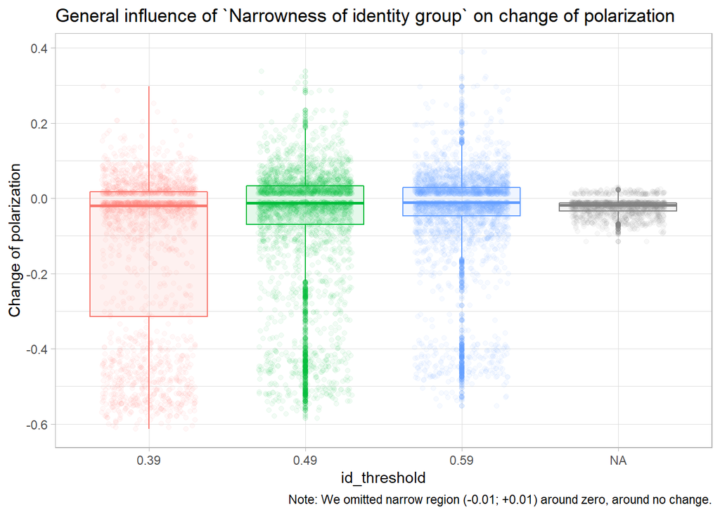

```r
df %>% filter(ESBG_dcat != "Roughly equal") %>%
  ggplot() +
  aes(y = ESBG_diff, x = id_threshold, fill = id_threshold, col = id_threshold ) +
  geom_boxplot(alpha = 0.1) +
  geom_jitter(alpha = 0.05, width = 0.3) +
  labs(caption = "Note: We omitted narrow region (-0.01; +0.01) around zero, around no change.",
       title = "General influence of `Narrowness of identity group` on change of polarization",
       y = "Change of polarization")+
  guides(fill = "none", color = "none") +
  theme_light()
```

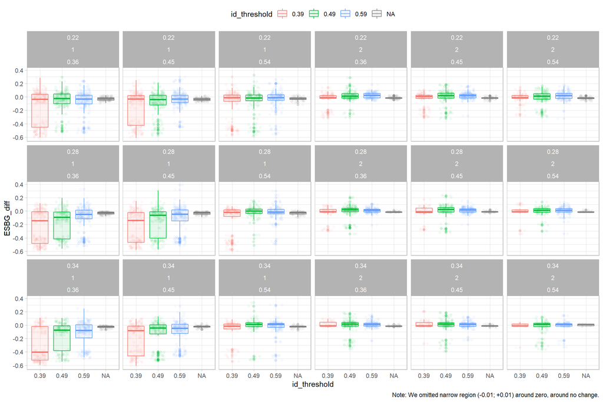

```r
df %>% filter(ESBG_dcat != "Roughly equal") %>%
  ggplot() +
  aes(y = ESBG_diff, x = id_threshold, fill = id_threshold, col = id_threshold ) +
  facet_wrap(vars(boundary, opinions, conformity), nrow = 3) +
  geom_boxplot(alpha = 0.1) +
  geom_jitter(alpha = 0.05, width = 0.3) +
  labs(caption = "Note: We omitted narrow region (-0.01; +0.01) around zero, around no change.") +
  theme_light() +
  theme(legend.position = "top")
```